# go-bike-go-slideshow slides

### Exploration of the Ford GoBike Dataset!

In this investigation I looked at the GoBike dataset, available on their website and tried to find some interesting, not so obvious and surprising insights from their data.

## Dataset overview

#### How is the data structured?

After cleaning the data has about 450000 rows and 11 columns, including but not limited to - age of the rider, gender, duration, and start and end points of the ride.

### What does the age distribution of the audience look like?

From the graph we are able to understand that people in their early 30s are more likely to use the bike sharing app.

People in their early 30s are generally financially stable and hence are more likely to opt in for a subsription. This also means that the sales team could use this value to optimize their pricing.

#### The most common age is 34, the average age is 38.

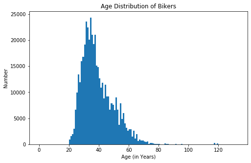

```python
binsize = 1
bins = np.arange(0, df['member_age'].max()+binsize, binsize)

plt.figure(figsize=[8, 5])
plt.hist(data = df, x = 'member_age', bins = bins)
plt.xlabel('Age (in Years)')
plt.ylabel('Number')
plt.title('Age Distribution of Bikers')
plt.show()
```

### Is there a relationship between the age of the user and the ride duration?

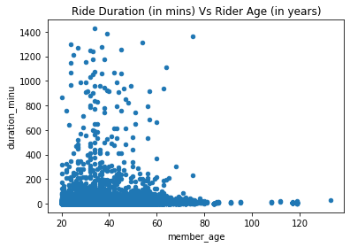

```python
df.sample(50000).plot.scatter(x='member_age',y='duration_minu', title="Ride Duration (in mins) Vs Rider Age (in years)");
```

### How does the gender distribution look like for all members?

From the data we can conclude that more men are likely to try the bikes.

Why? I guess this might be due to the fact the men usually wear pants and Shirts or T-Shirts, which make it easy for them to ride bikes. Women on the other hand might prefer to wear long dresses, skirts and other types of clothes which might make it difficult for them the to use the bikes.

Maybe, women just prefer to take the car or the bus. 🤷🏽‍♀️

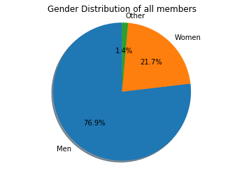

```python
import matplotlib.pyplot as plt

# Pie chart, where the slices will be ordered and plotted counter-clockwise:
labels = 'Men', 'Women', 'Other'
sizes = [(df['member_gender']==0).sum(), (df['member_gender']==1).sum(),(df['member_gender']==2).sum()]
explode = (0, 0, 0)  # only "explode" the 2nd slice (i.e. 'Hogs')

fig1, ax1 = plt.subplots()
ax1.pie(sizes, explode=explode, labels=labels, autopct='%1.1f%%',
        shadow=True, startangle=90)
ax1.axis('equal')  # Equal aspect ratio ensures that pie is drawn as a circle.
plt.title("Gender Distribution of all members")
plt.show()
```

### How does the gender distribution look like for subscribers?

Though the number of men are more who are regular users, women amount to about 31% of the total number of subscribers. This means women are about 1/3 more likely to opt for the subscription as compared to men.

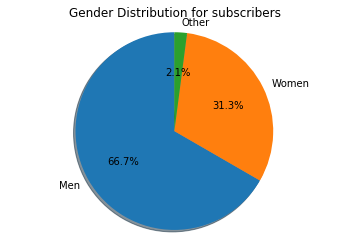

```python
labels = 'Men', 'Women', 'Other'
sizes = [df.query('member_gender == 0 & member_subscriber == True').sum()[0],
         df.query('member_gender == 1 & member_subscriber == True').sum()[0],
         df.query('member_gender == 2 & member_subscriber == True').sum()[0]]
explode = (0, 0, 0)
fig1, ax1 = plt.subplots()
ax1.pie(sizes, explode=explode, labels=labels, autopct='%1.1f%%',
        shadow=True, startangle=90)
ax1.axis('equal')  # Equal aspect ratio ensures that pie is drawn as a circle.
plt.title("Gender Distribution for subscribers")
plt.show()
```

### Is there a difference between the riding habits of subscribers and customers?

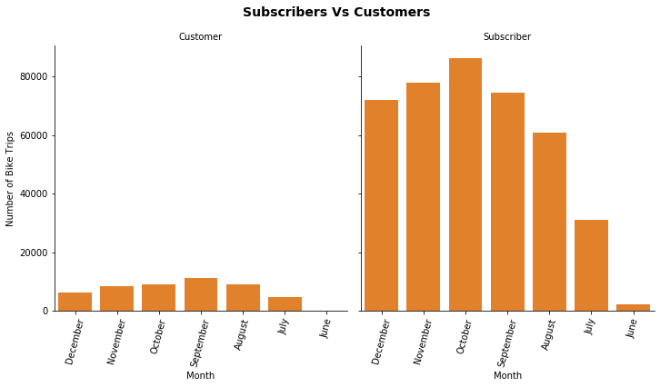

```python
df['start_time_month'] = df['start_time'].dt.strftime('%B')
graph = sb.catplot(data=df, x='start_time_month', col="user_type", kind='count', sharey = True, color = sb.color_palette()[1]);
graph.set_axis_labels("Month", "Number of Bike Trips");
graph.fig.suptitle('Subscribers Vs Customers', y=1.05, fontsize=14, fontweight='bold');
graph.set_xticklabels(rotation=75);
graph.set_titles("{col_name}");
```

### Does a specific age group / gender go for rides longer than the others?

From the visualizations we can derive the conclusion that women between 20-40 are more likely to go on longer biking trips than any other group. This is an interesting observation, but I can't really find a specific reason for this.

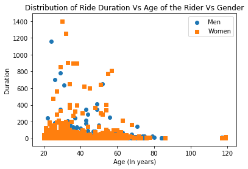

```python
markers = [[0, 'o'],
           [1, 's']]

for c, marker in markers:
    df_cat = df[df['member_gender'] == c]
    plt.scatter(data = df_cat.sample(5000), x = 'member_age', y = 'duration_minu', marker = marker);
plt.legend(['Men','Women']);
plt.xlabel("Age (In years)");
plt.ylabel("Duration");
plt.title("Distribution of Ride Duration Vs Age of the Rider Vs Gender");
```

### Which type of trips are more common, per gender per user type?

From the data we understand that round trips are less common by factor of 10! If it were upto me I would have thought this would have been the other way round. This means, customers are more likely to go from point A-B on their bikes and hence, having more number of stations for the bikes can be useful.

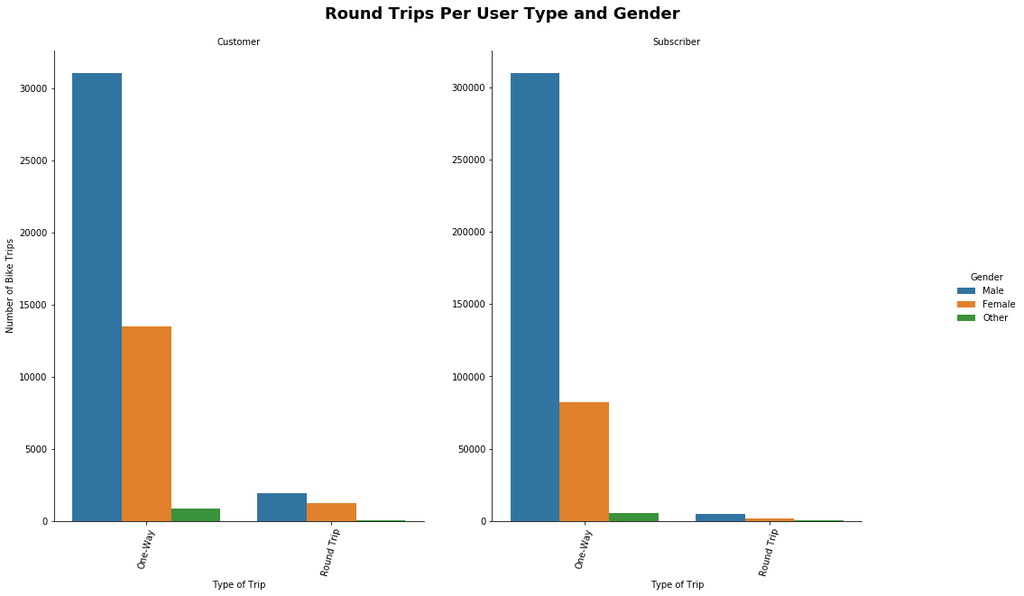

```python
# Monthly usage - user type and gender

graph = sb.catplot(data=df, x='round_trip', col="user_type", hue="member_gender_orgin", kind='count', sharey = False, height=10, aspect=0.5);
graph.set_axis_labels('Type of Trip', "Number of Bike Trips")
graph._legend.set_title('Gender')
graph.set_titles("{col_name}")
graph.fig.set_size_inches( 16, 8)
graph.fig.suptitle('Round Trips Per User Type and Gender', y=1.05, fontsize=18, fontweight='bold');
graph.set_xticklabels(rotation=75);
```

### Is there a relation between the month of the year and the total number bikers? How is it distributed across different genders?

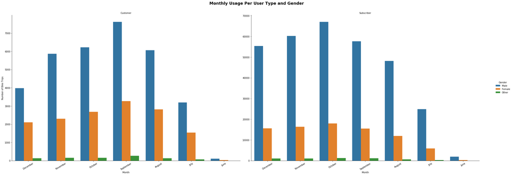

```python
# Monthly usage - user type and gender
graph = sb.catplot(data=df, x='start_time_month', col="user_type", hue="member_gender_orgin", kind='count', sharey = False, height=10, aspect=1.5);
graph.set_axis_labels("Month", "Number of Bike Trips")
graph._legend.set_title('Gender')
graph.set_xticklabels(rotation=30);
graph.set_titles("{col_name}")
graph.fig.suptitle('Monthly Usage Per User Type and Gender', y=1.05, fontsize=18, fontweight='bold');
```

## Summary

Thus we understand that Go Bike is an excellent initiative and a great business endeavour. This is beneficial for both the environment and for the cusotmers who can easily use the bikes to commute small distances.

Another great thing is the fact that the company decided to open source their datasets, which allowed us to perform this analysis!